# 3. 머신러닝 딥러닝중 이미지 처리에 필요한 numpy

### 5. 이미지 자료 & 브로드캐스트

- 컬러이미지를 array화 시키면 [행,열,[rgb]]
- PILLOW 모듈은 np.array로 해야하고, openCV모듈은 읽을때 array화 되어 있음.
- 컬러이미지는 한개의 픽셀에 [R,G,B]의 0~255 값으로 표현됨
- 컬러이미지에서 모든 값중 빨강색만 조정하고자 한다면 [:,:,0] 임 즉 모든행(:), 모든열(:) RGB의첫번째값(0)
- 컬러이미지에서 모든 값중 초록색만 조정하고자 한다면 [:,:,1] 임 즉 모든행(:), 모든열(:) RGB의첫번째값(1)
- 컬러이미지에서 모든 값중 파랑색만 조정하고자 한다면 [:,:,2] 임 즉 모든행(:), 모든열(:) RGB의첫번째값(2)

```python
import numpy as np
import matplotlib.pyplot as plt

### 검정색 만들기, 빈행열 제작
array=np.zeros((8,8,3),dtype=np.uint8)
print(array[0])  # 0으로 출력


array=np.zeros((8,8,3))
print(array[0])  #0.0으로 출력됨
```

```
[[0 0 0]
 [0 0 0]
 [0 0 0]
 [0 0 0]
 [0 0 0]
 [0 0 0]
 [0 0 0]
 [0 0 0]]
[[0. 0. 0.]
 [0. 0. 0.]
 [0. 0. 0.]
 [0. 0. 0.]
 [0. 0. 0.]
 [0. 0. 0.]
 [0. 0. 0.]
 [0. 0. 0.]]
```

```
▶-- 0 0 0 에서 rgb의 첫번째값만 255로 변경되면서 255 0 0 이 됨------------------
[[255   0   0]
 [255   0   0]
 [255   0   0]
 [255   0   0]
 [255   0   0]
 [255   0   0]
 [255   0   0]
 [255   0   0]]
▶-- 0 0 0 에서 rgb의 첫번째값만 255로 변경되면서 [255 0 0] 로 변환------------------
[[  0   0 255]
 [  0   0 255]
 [  0   0 255]
 [  0   0 255]
 [  0   0 255]
 [  0   0 255]
 [  0   0 255]
 [  0   0 255]]
▶-- 255 0 0 에서 rgb의 첫번째값을 0으로 변경하고, 0 0 0 의 2번째 값을 변경하여 [0 0 255] 로 변환------------------
[[  0   0 255]
 [  0   0 255]
 [  0   0 255]
 [  0   0 255]
 [  0   0 255]
 [  0   0 255]
 [  0   0 255]
 [  0   0 255]]
```

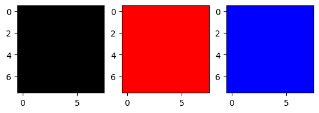

```python
array=np.zeros((8,8,3),dtype=np.uint8)
plt.subplot(1,3,1)
plt.imshow(array)

# 검정색(0,0,0) 을  red(255,0,0으로 바꿈

array[:,:,0]=255
print('▶-- 0 0 0 에서 rgb의 첫번째값만 255로 변경되면서 255 0 0 이 됨------------------')

plt.subplot(1,3,2)
plt.imshow(array)
print(array[0])

# 빨강(255,0,0) 을  blue(0,0,255)로 바꿈
array[:,:,0]=0
print('▶-- 0 0 0 에서 rgb의 첫번째값만 255로 변경되면서 [255 0 0] 로 변환------------------')
array[:,:,2]=255
plt.subplot(1,3,3)
print(array[0])
plt.imshow(array)


# blue
array[:,:,0]=0
array[:,:,2]=255
print('▶-- 255 0 0 에서 rgb의 첫번째값을 0으로 변경하고, 0 0 0 의 2번째 값을 변경하여 [0 0 255] 로 변환------------------')
print(array[0])
plt.subplot(1,3,3)
plt.imshow(array)
```

```
[[[0 0 0]
  [0 0 0]
  [0 0 0]
  [0 0 0]
  [0 0 0]
  [0 0 0]
  [0 0 0]
  [0 0 0]]

 [[0 0 0]
  [0 0 0]
  [0 0 0]
  [0 0 0]
  [0 0 0]
  [0 0 0]
```

[output cut: 180 more lines]

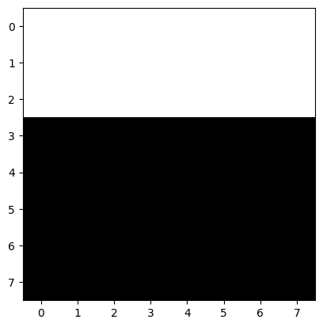

```python
# 3행까지만 흰색으로 채우기
### 검정색 만들기, 빈행열 제작
import numpy as np
import matplotlib.pyplot as plt
array=np.zeros((8,8,3),dtype=np.uint8)
print(array)
plt.imshow(array)

print(array[:3])
print(array)
print('-------------------------------------------------------')
array[:3]=255
print(array[:3])
plt.imshow(array)
```

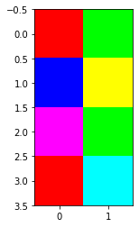

```python
######################
## 임의로 4행2열, 컬러 이미지를 제작함
######################
import numpy as np
import matplotlib.pyplot as plt

img=[[[255,0,0],[0,255,0]],
     [[0,0,255],[255,255,0]],
     [[255,0,255],[0,255,0]],
     [[255,0,0],[0,255,255]]]
np.shape(img)
plt.imshow(img)
```

[output not shown]

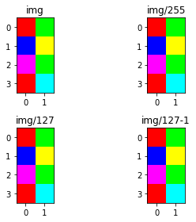

```
img: 0 255 (4, 2, 3)
img/255: 0.0 1.0 (4, 2, 3)
img/127: 0.0 2.0078740157480315 (4, 2, 3)
img/127-1: -1.0 1.0078740157480315 (4, 2, 3)
```

```python
# 참고: 이미지 자료는 화면에서 play하는 용도는 0~255나, 0~1이나 같음.
# 이미지 정규화(Normalization)임. 이 이미지 정규화(Normalization)은 작업한 사람밖에 모름
# 인공지능할때 255로 나누었는지 127로 나누었는지 모름.
# 인공지능 테스트할때는 정규화(Normalization)하고 똑같이 해야함.  255로 나누면 새 이미지로 255로 나눠야함.
# 그래서 작성한 사람이 안 알려주면 모름. 결과 잘 안나옴
# 인공지능 작업할때는 상황에 따라 255로, 127, 나누던지 127로 나누고 -1 하던지 그때 그때 이미지 상황에 따라서
# 작업이 달라지고, 정답은 없음.
# -그러나 0~255 보다는 -1~1 또는 0~1이 값이 작음으로 이미지 정규화(Normalization)을 권장함.
# 그래서 numpy로 받은 자료(npy나 npz 임)는 반드시 min, max를 확인해야함.

img=[[[255,0,0],[0,255,0]],
     [[0,0,255],[255,255,0]],
     [[255,0,255],[0,255,0]],
     [[255,0,0],[0,255,255]]]


#img
plt.subplot(221)
img=np.array(img)
plt.imshow(img)
plt.title('img')

#img/255
plt.subplot(222)
img_1=img/255
plt.imshow(img_1)
plt.title('img/255')

#img/127
plt.subplot(223)
img_2=img/127
plt.title('img/127')
plt.imshow(img_2)

#img/127-1
plt.subplot(224)
img_3=img/127-1
plt.imshow(img_3)
plt.title('img/127-1')
plt.tight_layout()
plt.show()

print('img:',np.min(img), np.max(img), np.shape(img))
print('img/255:',np.min(img_1), np.max(img_1), np.shape(img_1))
print('img/127:',np.min(img_2), np.max(img_2), np.shape(img_2))
print('img/127-1:',np.min(img_3), np.max(img_3), np.shape(img_3))
```

### 6. numpy의 행열 이어보기를 이용한 이미지를 여러개 한번에 보기

- 이미지를 여러개 열단위로 연결하거나(np.hstack)
- 또는 행단위로 연결(np.vstack) 하면됨

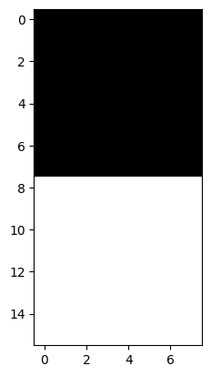

```python
img1=np.zeros((8,8,3))
img2=np.ones((8,8,3))
plt.imshow(np.vstack((img1,img2)))
```

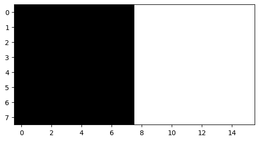

```python
img1=np.zeros((8,8,3))
img2=np.ones((8,8,3))
plt.imshow(np.hstack((img1,img2)))
```